# R Notebook

```r
rm(list=ls())
require(gam)
require(ggplot2)
require(dplyr)
require(MASS)
# Read in Data
# data from https://www.kaggle.com/mirichoi0218/insurance
insurance <- read.csv(file = file.path("insurance.csv"))
# General Summary of Insurance Data
# summary(insurance)
# Age Mean and Median look similar, so probably not skewed
# Sex - about the same males and females
# BMI - mean and median about the same so probably not skewed
# children max is 5 children min is 0
# Charges - Min 1122 Max - 63770
```

Histogram of charges

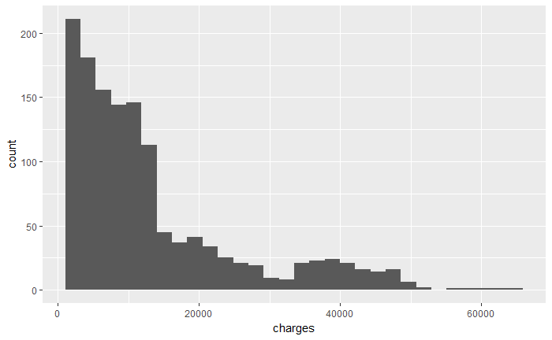

```r
qplot(x = charges, data = insurance)
```

Histogram of log(charges)

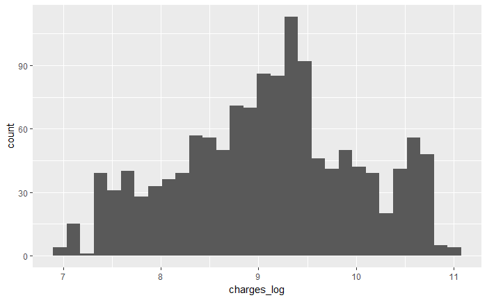

```r
# Fix skewness with log transformation
# Why do this beforehand? Skewness shouldn't be a probelm unless the residuals are non-normal as a result
insurance$charges_log <- log(insurance$charges)
qplot(x = charges_log, data = insurance)
```

Histograms of the continuous predictors, age and bmi, along with charges (both logged and not logged)

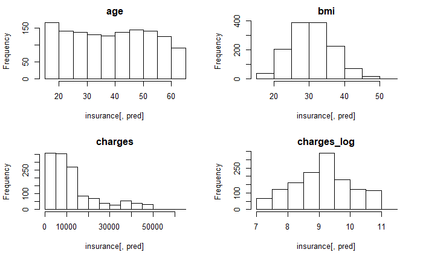

```r
insurance_predictors <- c('age', 'bmi', 'charges', 'log_charges')
# Look at distribution of numerical predictors
par(mfrow = c(2, 2))
for (pred in c(1, 3, 7, 8)){
  hist(insurance[, pred],
       main = names(insurance)[pred])

}
```

Mean charges for predictor variables:

```r
# Means of charges grouped by region, smoker, children, and sex
region.mean.charges <- insurance %>% group_by(region) %>% summarize(charge.means = mean(charges, na.rm = TRUE))
smoker.mean.charges <- insurance %>% group_by(smoker) %>% summarize(charge.means = mean(charges, na.rm = TRUE))
childern.mean.charges <- insurance %>% group_by(children) %>% summarize(charge.means = mean(charges, na.rm = TRUE))
sex.mean.charges <- insurance %>% group_by(sex) %>% summarize(charge.means = mean(charges, na.rm = TRUE))
# Means of BMI by bin
# BMI Cutoffs https://www.cdc.gov/healthyweight/assessing/bmi/adult_bmi/index.html
# Below 18.5 = Underweight
# 18.5 - 24.9 - NOmral or Healthy Weight
# 25.0 - 29.9 - Overweight
# > 30 - Obese
insurance.bmi.groups <-  insurance %>%
                          arrange(bmi) %>%
                          mutate(BMI_Categories = cut(bmi,
                                                      breaks = c(-Inf, 18.5, 24.9, 29.9, Inf),
                                                      labels = c('Underweight', 'Normal', 'Overweight', 'Obese')))
bmi.mean.charges <- insurance.bmi.groups %>%
                      group_by(BMI_Categories) %>%
                      summarize(charge.means = mean(charges, na.rm = TRUE))
# Means of ages by group
# groups http://www.widener.edu/about/campus_resources/wolfgram_library/documents/life_span_chart_final.pdf
# Development Through life Grouping
insurance.age.groups <- insurance %>%
                        arrange(age) %>%
                        mutate(AGE_Categories_Life = cut(age,
                                                         breaks = c(17, 24, 34, 60, 75),
                                                         labels = c('Later Adolescence', 'Early Adulthood', 'Middle Adulthood' ,'Later Adulthood'))) %>%
                        mutate(AGE_Categories_Academic = cut(age,
                                                             breaks = c(17, 25, 40, 60, 'INF'),
                                                             labels = c('Young Adult', 'Adulthood', 'Middle Age' ,'Older People')))
# mean ages for bins by life_categories
age_life.mean.charges <- insurance.age.groups %>% group_by(AGE_Categories_Life) %>% summarize(charge.means = mean(charges, na.rm = TRUE))
# mean ages for bins by Academic categories
age_academic.means.charges <- insurance.age.groups %>% group_by(AGE_Categories_Academic) %>% summarize(charge.means = mean(charges))
region.mean.charges
```

| region | charge.means |
| --- | --- |
| northeast | 13406.38 |
| northwest | 12417.58 |
| southeast | 14735.41 |
| southwest | 12346.94 |

```r
smoker.mean.charges
```

| smoker | charge.means |
| --- | --- |
| no | 8434.268 |
| yes | 32050.232 |

```r
childern.mean.charges
```

| children | charge.means |
| --- | --- |
| 0 | 12365.976 |
| 1 | 12731.172 |
| 2 | 15073.564 |
| 3 | 15355.318 |
| 4 | 13850.656 |
| 5 | 8786.035 |

```r
sex.mean.charges
```

| sex | charge.means |
| --- | --- |
| female | 12569.58 |
| male | 13956.75 |

```r
bmi.mean.charges
```

| BMI_Categories | charge.means |
| --- | --- |
| Underweight | 8657.621 |
| Normal | 10404.900 |
| Overweight | 11006.810 |
| Obese | 15491.542 |

```r
age_academic.means.charges
```

| AGE_Categories_Academic | charge.means |
| --- | --- |
| Young Adult | 9087.016 |
| Adulthood | 11096.680 |
| Middle Age | 15888.758 |
| Older People | 21063.163 |

Cross tab of region by children:

```r
table(insurance$region, insurance$children)
```

```
              0   1   2   3   4   5
  northeast 147  77  51  39   7   3
  northwest 132  74  66  46   6   1
  southeast 157  95  66  35   5   6
  southwest 138  78  57  37   7   8
```

Cross tab of sex by children:

```r
table(insurance$sex, insurance$children)
```

```
           0   1   2   3   4   5
  female 289 158 119  77  11   8
  male   285 166 121  80  14  10
```

Tests of independence:

```r
sex.region <- table(insurance$sex, insurance$region)
chisq.test(sex.region) # non-significant therefore independent
```

```
    Pearson's Chi-squared test

data:  sex.region
X-squared = 0.43514, df = 3, p-value = 0.9329
```

```r
smoker.region <- table(insurance$smoker, insurance$region)
chisq.test(smoker.region) # marginially non-significant (suprising!)
```

```
    Pearson's Chi-squared test

data:  smoker.region
X-squared = 7.3435, df = 3, p-value = 0.06172
```

Fitting the Generalized Additive Model:

```r
#################### Fitting Generalized Additive Model #############################
# Fit a Generalized Additive Model
gam1 <- gam(charges_log ~ s(age, df = 6) + sex + s(bmi, df = 6) + as.factor(children) + smoker + region , data = insurance)
summary(gam1) #AIC = 1623.196
```

```
Call: gam(formula = charges_log ~ s(age, df = 6) + sex + s(bmi, df = 6) +
    as.factor(children) + smoker + region, data = insurance)
Deviance Residuals:
     Min       1Q   Median       3Q      Max
-0.86527 -0.22591 -0.06493  0.08145  2.17477

(Dispersion Parameter for gaussian family taken to be 0.1933)

    Null Deviance: 1130.474 on 1337 degrees of freedom
Residual Deviance: 254.2532 on 1315 degrees of freedom
AIC: 1623.196

Number of Local Scoring Iterations: 2

Anova for Parametric Effects
                      Df Sum Sq Mean Sq   F value    Pr(>F)
s(age, df = 6)         1 312.89  312.89 1618.2900 < 2.2e-16 ***
sex                    1   0.31    0.31    1.5932    0.2071
s(bmi, df = 6)         1   6.63    6.63   34.3113 5.927e-09 ***
as.factor(children)    5  22.97    4.59   23.7595 < 2.2e-16 ***
smoker                 1 521.40  521.40 2696.7033 < 2.2e-16 ***
region                 3   4.61    1.54    7.9533 2.949e-05 ***
Residuals           1315 254.25    0.19
---
Signif. codes:  0 ‘***’ 0.001 ‘**’ 0.01 ‘*’ 0.05 ‘.’ 0.1 ‘ ’ 1

Anova for Nonparametric Effects
                    Npar Df Npar F   Pr(F)
(Intercept)
s(age, df = 6)            5 3.6930 0.00253 **
sex
s(bmi, df = 6)            5 2.0557 0.06845 .
as.factor(children)
smoker
region
---
Signif. codes:  0 ‘***’ 0.001 ‘**’ 0.01 ‘*’ 0.05 ‘.’ 0.1 ‘ ’ 1
```

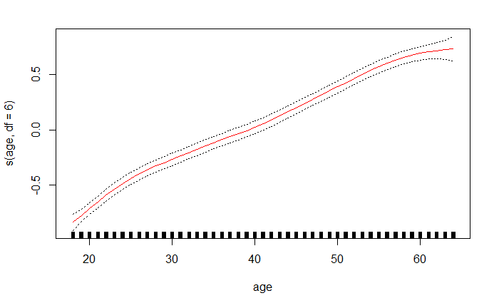

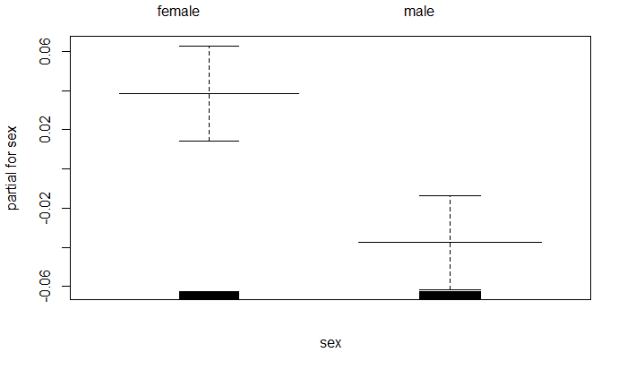

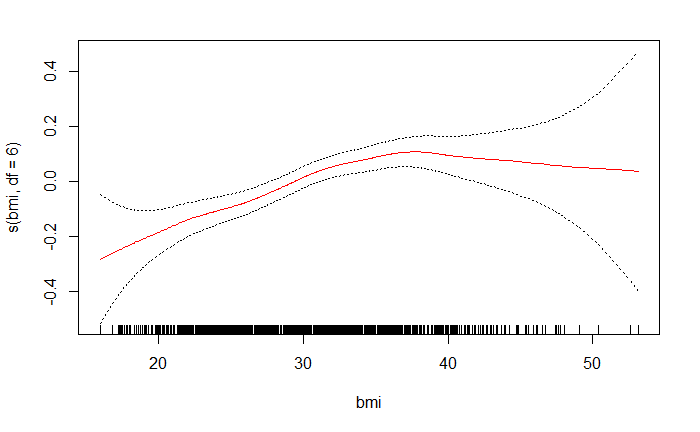

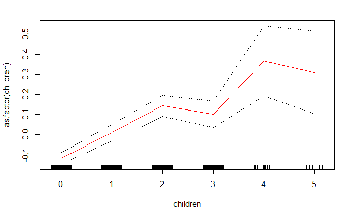

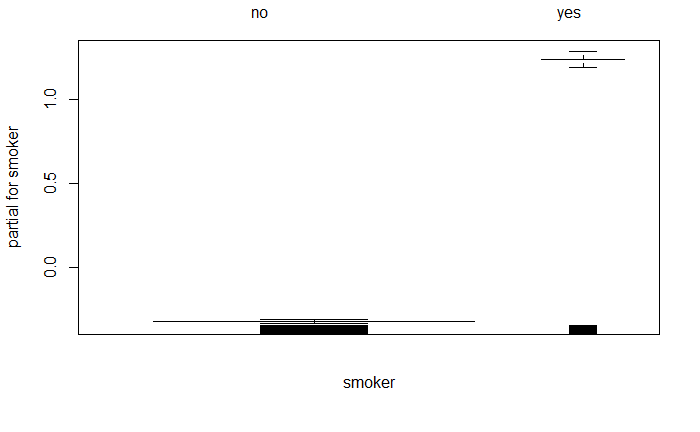

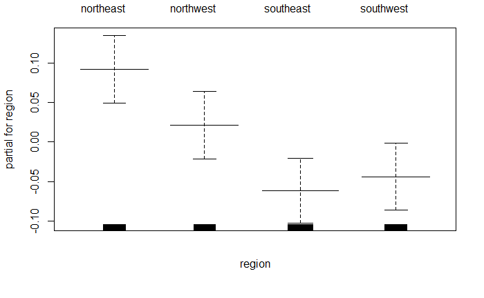

```r
par(mfrow=c(1,1))
plot(gam1, se=TRUE, col='red')
```

```r
#add binned age and bmi variables to one dataset
insurance.age.bmi.groups <- insurance %>% arrange(bmi) %>% mutate(BMI_Categories = cut(bmi,
                                                                                       breaks = c(-Inf, 18.5, 24.9, 29.9, Inf),
                                                                                       labels = c('Underweight', 'Normal', 'Overweight', 'Obese'))) %>%
                            arrange(age) %>% mutate(AGE_Categories_Life = cut(age,
                                                                              breaks = c(17, 24, 34, 60, 75),
                                                                              labels = c('Later Adolescence', 'Early Adulthood', 'Middle Adulthood' ,'Later Adulthood'))) %>%
                            mutate(AGE_Categories_Academic = cut(age,
                                                                 breaks = c(17, 25, 40, 60, 'INF'),
                                                                 labels = c('Young Adult', 'Adulthood', 'Middle Age' ,'Older People')))
#Try GAM with binned age and bmi
gam2 <- gam(charges_log ~ sex + as.factor(children) + smoker + region + AGE_Categories_Academic + BMI_Categories, data = insurance.age.bmi.groups)
summary(gam2) #AIC = 1814.741
```

```
Call: gam(formula = charges_log ~ sex + as.factor(children) + smoker +
    region + AGE_Categories_Academic + BMI_Categories, data = insurance.age.bmi.groups)
Deviance Residuals:
     Min       1Q   Median       3Q      Max
-0.94924 -0.29200 -0.06984  0.18263  2.28133

(Dispersion Parameter for gaussian family taken to be 0.2241)

    Null Deviance: 1130.474 on 1337 degrees of freedom
Residual Deviance: 296.0289 on 1321 degrees of freedom
AIC: 1814.741

Number of Local Scoring Iterations: 2

Anova for Parametric Effects
                          Df Sum Sq Mean Sq   F value    Pr(>F)
sex                        1   0.04    0.04    0.1600  0.689217
as.factor(children)        5  38.22    7.64   34.1109 < 2.2e-16 ***
smoker                     1 496.22  496.22 2214.3130 < 2.2e-16 ***
region                     3   2.56    0.85    3.8132  0.009772 **
AGE_Categories_Academic    3 287.98   95.99  428.3575 < 2.2e-16 ***
BMI_Categories             3   9.43    3.14   14.0296 5.254e-09 ***
Residuals               1321 296.03    0.22
---
Signif. codes:  0 ‘***’ 0.001 ‘**’ 0.01 ‘*’ 0.05 ‘.’ 0.1 ‘ ’ 1
```

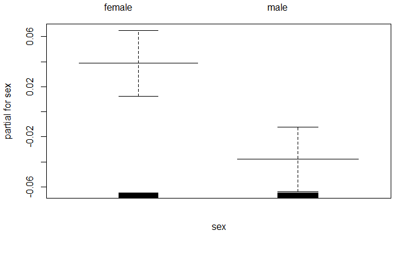

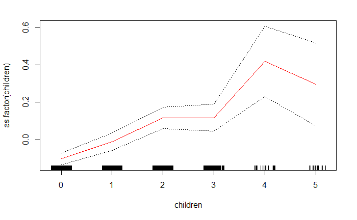

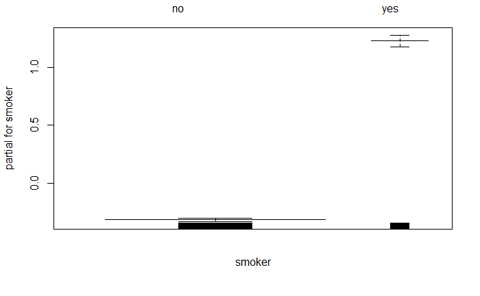

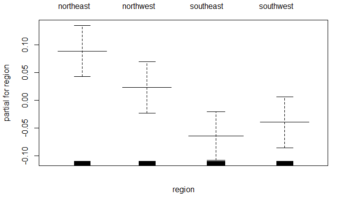

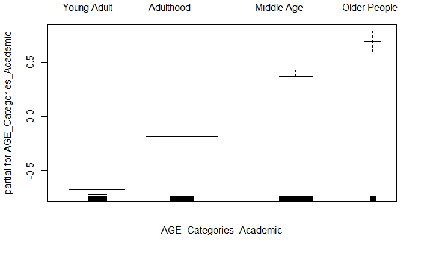

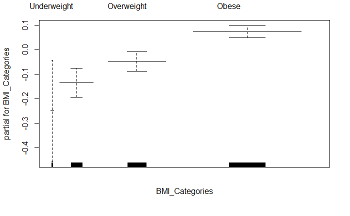

```r
plot(gam2, se=TRUE, col='red')
```

```r
##need to restart R session if you have loaded the gam library in order to load the mgcv
require(mgcv)
#Try with the mgcv version of gam for continuous age and bmi
gam3 <- gam(charges_log ~ s(age) + sex + s(bmi) + as.factor(children) + smoker + region, data = insurance)
summary(gam3)
```

```
Family: gaussian
Link function: identity

Formula:
charges_log ~ s(age) + sex + s(bmi) + as.factor(children) + smoker +
    region

Parametric coefficients:
                     Estimate Std. Error t value Pr(>|t|)
(Intercept)           8.79202    0.03140 280.012  < 2e-16 ***
sexmale              -0.07591    0.02415  -3.143 0.001710 **
as.factor(children)1  0.12584    0.03206   3.925 9.11e-05 ***
as.factor(children)2  0.26105    0.03551   7.351 3.45e-13 ***
as.factor(children)3  0.22008    0.04082   5.391 8.27e-08 ***
as.factor(children)4  0.48498    0.09054   5.356 1.00e-07 ***
as.factor(children)5  0.41935    0.10645   3.939 8.60e-05 ***
smokeryes             1.55857    0.03010  51.782  < 2e-16 ***
regionnorthwest      -0.06995    0.03465  -2.019 0.043720 *
regionsoutheast      -0.15554    0.03479  -4.471 8.46e-06 ***
regionsouthwest      -0.13460    0.03474  -3.874 0.000112 ***
---
Signif. codes:  0 ‘***’ 0.001 ‘**’ 0.01 ‘*’ 0.05 ‘.’ 0.1 ‘ ’ 1

Approximate significance of smooth terms:
         edf Ref.df      F  p-value
s(age) 4.525  5.543 289.95  < 2e-16 ***
s(bmi) 2.282  2.918  16.17 4.56e-10 ***
---
Signif. codes:  0 ‘***’ 0.001 ‘**’ 0.01 ‘*’ 0.05 ‘.’ 0.1 ‘ ’ 1

R-sq.(adj) =  0.771   Deviance explained = 77.4%
GCV = 0.19585  Scale est. = 0.19324   n = 1338
```

```r
    ## R^2 = 0.771 deviance explained = 77.4%
    ## all variables significant
# plot(gam3)
## https://kevintshoemaker.github.io/NRES-746/GAMs.html#references_(weblinks):_with_r_codes
# anova.gam(gam3)
# AIC(gam3) #1617.343
#
# plot(gam3, residuals = TRUE)  # plots model output, showing partial residuals
# plot(gam3, seWithMean = TRUE) # plots model output, with intercept confidence intervals
# plot(gam3, scheme = 1, unconditional = TRUE)  # another plotting method. Note that "scheme=2" is the default shown in previous plots
#
# gam.check(gam3)  # checking the smoothing basis dimensions by running some diagnostic checks
# # K' was observed to be 9.0 and K' = K - 1. So, even though we didn't set K, the default k used by the algorithm was 10
# # the default method for estimating smoothness is GCV, which is a cross-validation method. Let's change it to a likelihood method using REML
# gam3a <- gam(charges_log ~ s(age) + sex + s(bmi) + as.factor(children) + smoker + region, data = insurance, method = "REML")
# summary(gam3a)
#   ## R^2 = 0.771 deviance explained = 77.4%
#   ## all variables significant
# AIC(gam3a) #1620.975
#
# # #specify k value
# # gam3b <- gam(charges_log ~ s(age, k = 25) + sex + s(bmi, k = 25) + as.factor(children) + smoker + region, data = insurance)
# # summary(gam3b)
# # gam.check(gam3b)
#
#Try with the mgcv version of gam for binned age and bmi
gam4 <- gam(charges_log ~ sex + as.factor(children) + smoker + region + AGE_Categories_Academic + BMI_Categories, data = insurance.age.bmi.groups)
summary(gam4)
```

```
Family: gaussian
Link function: identity

Formula:
charges_log ~ sex + as.factor(children) + smoker + region + AGE_Categories_Academic +
    BMI_Categories

Parametric coefficients:
                                    Estimate Std. Error t value Pr(>|t|)
(Intercept)                          7.88584    0.10827  72.837  < 2e-16 ***
sexmale                             -0.07670    0.02601  -2.949 0.003243 **
as.factor(children)1                 0.09169    0.03397   2.699 0.007044 **
as.factor(children)2                 0.21858    0.03760   5.813 7.67e-09 ***
as.factor(children)3                 0.21973    0.04369   5.029 5.60e-07 ***
as.factor(children)4                 0.52249    0.09729   5.371 9.27e-08 ***
as.factor(children)5                 0.39769    0.11423   3.481 0.000515 ***
smokeryes                            1.54411    0.03239  47.675  < 2e-16 ***
regionnorthwest                     -0.06540    0.03728  -1.754 0.079614 .
regionsoutheast                     -0.15283    0.03693  -4.138 3.72e-05 ***
regionsouthwest                     -0.12795    0.03740  -3.421 0.000644 ***
AGE_Categories_AcademicAdulthood     0.48447    0.03757  12.896  < 2e-16 ***
AGE_Categories_AcademicMiddle Age    1.06746    0.03483  30.647  < 2e-16 ***
AGE_Categories_AcademicOlder People  1.36166    0.05689  23.936  < 2e-16 ***
BMI_CategoriesNormal                 0.11555    0.10868   1.063 0.287899
BMI_CategoriesOverweight             0.20342    0.10704   1.901 0.057584 .
BMI_CategoriesObese                  0.32423    0.10628   3.051 0.002328 **
---
Signif. codes:  0 ‘***’ 0.001 ‘**’ 0.01 ‘*’ 0.05 ‘.’ 0.1 ‘ ’ 1


R-sq.(adj) =  0.735   Deviance explained = 73.8%
GCV = 0.22698  Scale est. = 0.22409   n = 1338
```

```r
  ##R^2 = .735 Deviance explained 73.8%
# plot(gam4)
# anova.gam(gam4)
# AIC(gam4) #1814.741
```

From the generalized additive model, we see that there is a very linear trend in age and charges. As you get older the health insurance charges increase. We also see that health costs tend to be higher for females than males. The charges tend to increase as body mass index increases until about 38 and then it levels off. The charges increase as the number of children increases between 0 and 2 children, then it levels off between 2 and 3 children. The charges increase again from 3 to 4 children and then levels off between 4 and 5 children. As expected, the health charges are much higher for smokers than non-smokers. Finally, the charges are highest in the northeast than any of the other regions. The second highest is the northwest. The southeast has the lowest health charges of all of the regions.